# Tipos de errores cuadrados

08/05, 2019

## Objetivos del práctico

- Entender los distintos tipos de errores cuadrados
  - Tipo I
  - Tipo II
  - Tipo III
- Cuando usar cada tipo de medida de error cuadrado
  - Tipo I (Diseños anidados)
  - Tipo II (Diseños factoriales sin interacción)
  - Tipo III (Diseños factoriales con interacción)
- Como implementarlo en R
- Solo importa en ANOVAS de dos o mas factores

## Antes de empezar

- Función `Anova`: Nos permite medir diferencias entre dos modelos lineales o ANOVAS

```r
anova(aov(mpg ~ am, data =mtcars), aov(mpg ~ am + cyl, data =mtcars))
```

```
## Analysis of Variance Table
##
## Model 1: mpg ~ am
## Model 2: mpg ~ am + cyl
##   Res.Df    RSS Df Sum of Sq      F    Pr(>F)
## 1     30 720.90
## 2     29 271.36  1    449.53 48.041 1.285e-07 ***
## ---
## Signif. codes:  0 '***' 0.001 '**' 0.01 '*' 0.05 '.' 0.1 ' ' 1
```

Usaremos esta función para explicar los tipos de errores cuadrados

## Error tipo I (Error por defecto de R)

- *Cuando usarlo*: Modelos anidados, anovas de una vía
- *Cuando no usarlo*: Modelos factoriales (El orden de los factores importa)

```r
aov(mpg ~ am*cyl, data = mtcars)
aov(mpg ~ cyl*am, data = mtcars)
```

| am primero term | am primero df | am primero sumsq | am primero p.value | cyl primero term1 | cyl primero df1 | cyl primero sumsq1 | cyl primero p.value1 |
| --- | --- | --- | --- | --- | --- | --- | --- |
| am | 1 | 405.15059 | 0.0000002 | cyl | 1 | 817.71295 | 0.0000000 |
| cyl | 1 | 449.53448 | 0.0000001 | am | 1 | 36.97211 | 0.0479300 |
| am:cyl | 1 | 29.43939 | 0.0755069 | cyl:am | 1 | 29.43939 | 0.0755069 |
| Residuals | 28 | 241.92273 | NA | Residuals | 28 | 241.92273 | NA |

## ¿Por que cambian los valores?

Errores cuadrados secuenciales `y ~ A + B + *A:B` esto se desglosa así:

- Primero como explica A los datos (`y ~ A`)
- Luego como explica B los datos después de que A explico los datos (`y ~ B|A`)
- Finalmente como explica la interacción dado lo que ya explican ambas variables en conjunto (`y ~ A:B| A + B`)
- Por eso es bueno para sistemas anidados

## Anotemos los cuadrados del ANOVA

```r
broom::tidy(aov(uptake ~ Treatment*Type, data = CO2))
```

| term | df | sumsq | meansq | statistic | p.value |
| --- | --- | --- | --- | --- | --- |
| Treatment | 1 | 988.1144 | 988.11440 | 15.41641 | 0.0001817 |
| Type | 1 | 3365.5344 | 3365.53440 | 52.50856 | 0.0000000 |
| Treatment:Type | 1 | 225.7296 | 225.72964 | 3.52180 | 0.0642128 |
| Residuals | 80 | 5127.5971 | 64.09496 | NA | NA |

## Cuanto explica Treatment

Treatment

```r
anova(aov(uptake ~ 1, data = CO2), aov(uptake ~ Treatment, data = CO2))
```

```
## Analysis of Variance Table
##
## Model 1: uptake ~ 1
## Model 2: uptake ~ Treatment
##   Res.Df    RSS Df Sum of Sq      F   Pr(>F)
## 1     83 9707.0
## 2     82 8718.9  1    988.11 9.2931 0.003096 **
## ---
## Signif. codes:  0 '***' 0.001 '**' 0.01 '*' 0.05 '.' 0.1 ' ' 1
```

## Cuanto explica Treatment

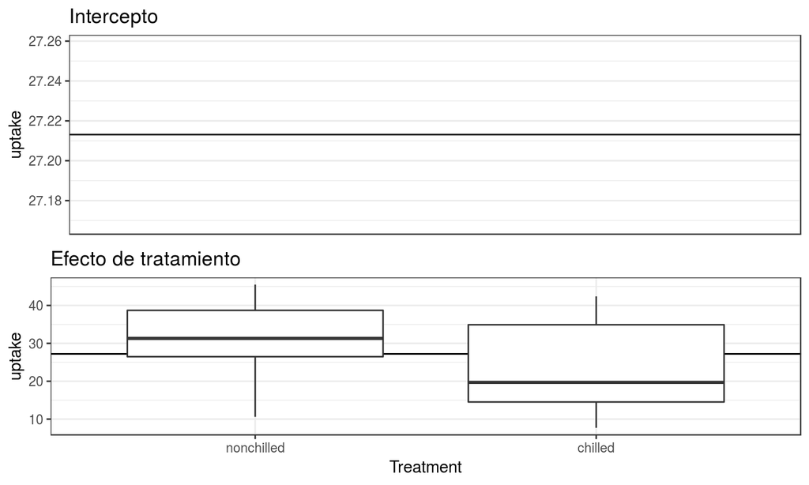

## Cuanto explica Type dado Treatment

```r
anova(aov(uptake ~ Treatment, data = CO2), aov(uptake ~ Treatment + Type, data = CO2))
```

```
## Analysis of Variance Table
##
## Model 1: uptake ~ Treatment
## Model 2: uptake ~ Treatment + Type
##   Res.Df    RSS Df Sum of Sq      F    Pr(>F)
## 1     82 8718.9
## 2     81 5353.3  1    3365.5 50.923 3.679e-10 ***
## ---
## Signif. codes:  0 '***' 0.001 '**' 0.01 '*' 0.05 '.' 0.1 ' ' 1
```

## Cuanto explica Type dado Treatment

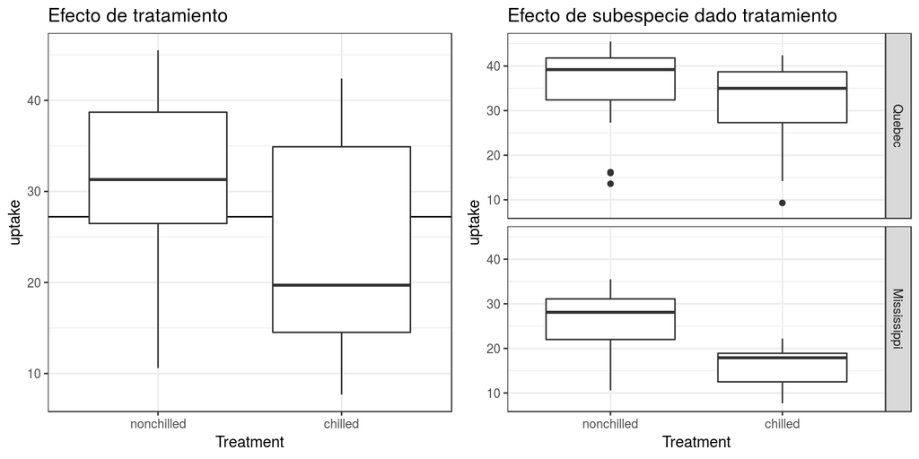

## Cuanto explica la interaccion dadas ambas variables

```r
anova(aov(uptake ~ Treatment + Type, data = CO2), aov(uptake ~
    Treatment + Type + Treatment:Type, data = CO2))
```

```
## Analysis of Variance Table
##
## Model 1: uptake ~ Treatment + Type
## Model 2: uptake ~ Treatment + Type + Treatment:Type
##   Res.Df    RSS Df Sum of Sq      F  Pr(>F)
## 1     81 5353.3
## 2     80 5127.6  1    225.73 3.5218 0.06421 .
## ---
## Signif. codes:  0 '***' 0.001 '**' 0.01 '*' 0.05 '.' 0.1 ' ' 1
```

## Cuanto explica la interaccion dadas ambas variables

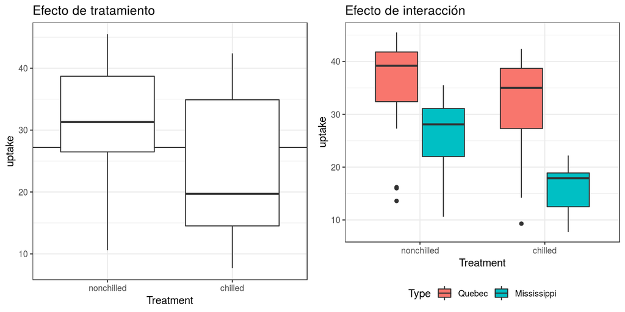

## Error tipo II

- *Cuando usarlo*: Cuando no hay interacciones (el más poderoso), anovas de una vía (orden no importa)
- *Cuando no usarlo*: Modelos factoriales interacciones fuertes

```r
library(car)
Anova(aov(mpg ~ am*cyl, data = mtcars), type = 2)
```

```
## Anova Table (Type II tests)
##
## Response: mpg
##           Sum Sq Df F value    Pr(>F)
## am         36.97  1  4.2791   0.04793 *
## cyl       449.53  1 52.0289 7.503e-08 ***
## am:cyl     29.44  1  3.4073   0.07551 .
## Residuals 241.92 28
## ---
## Signif. codes:  0 '***' 0.001 '**' 0.01 '*' 0.05 '.' 0.1 ' ' 1
```

```r
Anova(aov(mpg ~ cyl*am, data = mtcars), type = 2)
```

```
## Anova Table (Type II tests)
##
## Response: mpg
##           Sum Sq Df F value    Pr(>F)
## cyl       449.53  1 52.0289 7.503e-08 ***
## am         36.97  1  4.2791   0.04793 *
## cyl:am     29.44  1  3.4073   0.07551 .
## Residuals 241.92 28
## ---
## Signif. codes:  0 '***' 0.001 '**' 0.01 '*' 0.05 '.' 0.1 ' ' 1
```

## ¿Cual es la diferencia con el tipo 1?

[output not shown]

## Orden de los errores

Errores cuadrados de `y ~ A + B + *A:B` se desglosan así:

- Primero como explica A los datos despues de que B explico los datos (`y ~ A|B`)
- Luego como explica B los datos después de que A explico los datos (`y ~ B|A`)
- Finalmente como explica la interacción dado lo que ya explican ambas variables en conjunto (`y ~ A:B| A + B`)
- Por le da última prioridad a las interacciones
  - Bueno si nos interesan efectos principales
  - Malo si nos interesan más las interacciones

## Anotemos los cuadrados del ANOVA

```r
Anova(aov(mpg ~ am*cyl, data = mtcars), type = 2)
```

```
## Anova Table (Type II tests)
##
## Response: mpg
##           Sum Sq Df F value    Pr(>F)
## am         36.97  1  4.2791   0.04793 *
## cyl       449.53  1 52.0289 7.503e-08 ***
## am:cyl     29.44  1  3.4073   0.07551 .
## Residuals 241.92 28
## ---
## Signif. codes:  0 '***' 0.001 '**' 0.01 '*' 0.05 '.' 0.1 ' ' 1
```

## Cuanto explica am, cuando ya tomamos en cuenta cyl

```r
anova(aov(mpg ~ cyl, data = mtcars), aov(mpg ~ am + cyl, data = mtcars))
```

```
## Analysis of Variance Table
##
## Model 1: mpg ~ cyl
## Model 2: mpg ~ am + cyl
##   Res.Df    RSS Df Sum of Sq      F  Pr(>F)
## 1     30 308.33
## 2     29 271.36  1    36.972 3.9511 0.05635 .
## ---
## Signif. codes:  0 '***' 0.001 '**' 0.01 '*' 0.05 '.' 0.1 ' ' 1
```

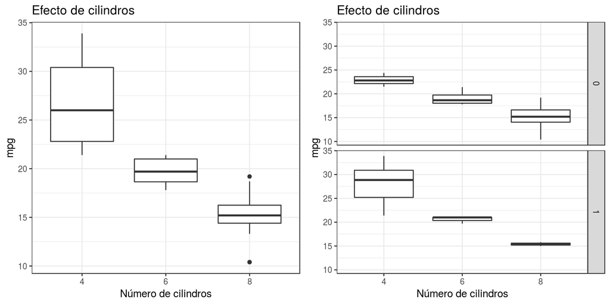

## Cuanto explica cyl, cuando ya tomamos en cuenta am

```r
anova(aov(mpg ~ am, data = mtcars), aov(mpg ~ am + cyl, data = mtcars))
```

```
## Analysis of Variance Table
##
## Model 1: mpg ~ am
## Model 2: mpg ~ am + cyl
##   Res.Df    RSS Df Sum of Sq      F    Pr(>F)
## 1     30 720.90
## 2     29 271.36  1    449.53 48.041 1.285e-07 ***
## ---
## Signif. codes:  0 '***' 0.001 '**' 0.01 '*' 0.05 '.' 0.1 ' ' 1
```

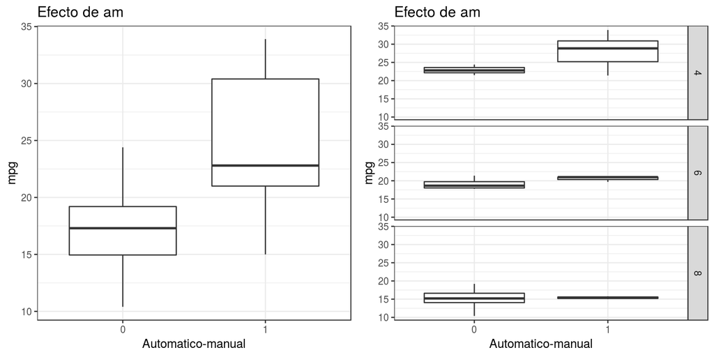

## Cuanto explica interacción, cuando ya tomamos en cuenta am y cyl

```r
anova(aov(mpg ~ am + cyl, data = mtcars), aov(mpg ~ am *cyl, data = mtcars))
```

```
## Analysis of Variance Table
##
## Model 1: mpg ~ am + cyl
## Model 2: mpg ~ am * cyl
##   Res.Df    RSS Df Sum of Sq      F  Pr(>F)
## 1     29 271.36
## 2     28 241.92  1    29.439 3.4073 0.07551 .
## ---
## Signif. codes:  0 '***' 0.001 '**' 0.01 '*' 0.05 '.' 0.1 ' ' 1
```

## Cuanto explica interacción

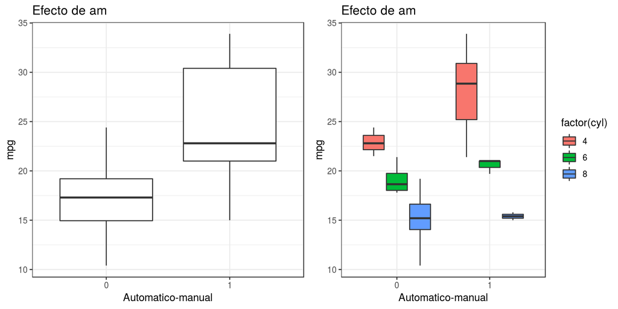

## Error tipo III

- *Cuando usarlo*: Cuando hay interacciones, diseños desbalanceados, anovas de una vía (orden no importa)
- *Cuando no usarlo*: Cuando las interacciones son fuertes no permite detectar efectos principales

```r
Anova(aov(mpg ~ am*cyl, data = mtcars), type = 3)
```

```
## Anova Table (Type III tests)
##
## Response: mpg
##             Sum Sq Df F value    Pr(>F)
## (Intercept) 810.20  1 93.7719 1.948e-10 ***
## am           48.28  1  5.5879 0.0252577 *
## cyl         167.65  1 19.4033 0.0001407 ***
## am:cyl       29.44  1  3.4073 0.0755069 .
## Residuals   241.92 28
## ---
## Signif. codes:  0 '***' 0.001 '**' 0.01 '*' 0.05 '.' 0.1 ' ' 1
```

## ¿Cual es la diferencia con el tipo 2?

```
## Anova Table (Type II tests)
##
## Response: mpg
##           Sum Sq Df F value    Pr(>F)
## am         36.97  1  4.2791   0.04793 *
## cyl       449.53  1 52.0289 7.503e-08 ***
## am:cyl     29.44  1  3.4073   0.07551 .
## Residuals 241.92 28
## ---
## Signif. codes:  0 '***' 0.001 '**' 0.01 '*' 0.05 '.' 0.1 ' ' 1
```

```
## Anova Table (Type III tests)
##
## Response: mpg
##             Sum Sq Df F value    Pr(>F)
## (Intercept) 810.20  1 93.7719 1.948e-10 ***
## am           48.28  1  5.5879 0.0252577 *
## cyl         167.65  1 19.4033 0.0001407 ***
## am:cyl       29.44  1  3.4073 0.0755069 .
## Residuals   241.92 28
## ---
## Signif. codes:  0 '***' 0.001 '**' 0.01 '*' 0.05 '.' 0.1 ' ' 1
```

## Orden de los errores

Errores cuadrados de`y ~ A + B + *A:B` se desglosan así:

- Primero como explica A los datos despues de que B y las interacciones lo explicaron (`y ~ A|B + A:B`)
- Luego como explica B los datos después de que A e interacciones explicaran los datos (`y ~ B|A + A:B`)
- Finalmente como explica la interacción dado lo que ya explican ambas variables en conjunto (`y ~ A:B| A + B`)
- Solo le da a cada variable lo que explica por si sola
  - Malo si nos interesan mas los efectos principales
  - Bueno si nos interesan más las interacciones

## Anotemos los cuadrados del ANOVA

```r
Anova(aov(mpg ~ am*cyl, data = mtcars), type = 3)
```

```
## Anova Table (Type III tests)
##
## Response: mpg
##             Sum Sq Df F value    Pr(>F)
## (Intercept) 810.20  1 93.7719 1.948e-10 ***
## am           48.28  1  5.5879 0.0252577 *
## cyl         167.65  1 19.4033 0.0001407 ***
## am:cyl       29.44  1  3.4073 0.0755069 .
## Residuals   241.92 28
## ---
## Signif. codes:  0 '***' 0.001 '**' 0.01 '*' 0.05 '.' 0.1 ' ' 1
```

## Cuanto explica am, cuando ya tomamos en cuenta cyl y las interacciones

```r
anova(aov(mpg ~ cyl, data = mtcars), aov(mpg ~ am + am:cyl, data = mtcars))
```

```
## Analysis of Variance Table
##
## Model 1: mpg ~ cyl
## Model 2: mpg ~ am + am:cyl
##   Res.Df    RSS Df Sum of Sq F Pr(>F)
## 1     30 308.33
## 2     29 409.57  1   -101.23
```

## Cuanto explica cyl, cuando ya tomamos en cuenta am y las interacciones

```r
anova(aov(mpg ~ am, data = mtcars), aov(mpg ~ cyl + am:cyl, data = mtcars))
```

```
## Analysis of Variance Table
##
## Model 1: mpg ~ am
## Model 2: mpg ~ cyl + am:cyl
##   Res.Df   RSS Df Sum of Sq      F    Pr(>F)
## 1     30 720.9
## 2     29 290.2  1    430.69 43.039 3.466e-07 ***
## ---
## Signif. codes:  0 '***' 0.001 '**' 0.01 '*' 0.05 '.' 0.1 ' ' 1
```

## Cuanto explica interacción, cuando ya tomamos en cuenta am y cyl

```r
anova(aov(mpg ~ am + cyl, data = mtcars), aov(mpg ~ am *cyl, data = mtcars))
```

```
## Analysis of Variance Table
##
## Model 1: mpg ~ am + cyl
## Model 2: mpg ~ am * cyl
##   Res.Df    RSS Df Sum of Sq      F  Pr(>F)
## 1     29 271.36
## 2     28 241.92  1    29.439 3.4073 0.07551 .
## ---
## Signif. codes:  0 '***' 0.001 '**' 0.01 '*' 0.05 '.' 0.1 ' ' 1
```

## Exploren ANOVAS

Crearemos base de datos simulada con la funcion `SimulData`:

```r
SimulData <- function(MeanA1B1 = 20, MeanA1B2 = 20, MeanA1B3 = 20,
    MeanA2B1 = 40, MeanA2B2 = 40, MeanA2B3 = 40, N = 5) {
    data.frame(A = rep(c("A1", "A2"), each = 3 * N), B = rep(rep(c("B1",
        "B2", "B3"), each = N), times = 2), y = (c(rnorm(mean = MeanA1B1,
        n = N, sd = 5), rnorm(mean = MeanA1B2, n = N, sd = 5),
        rnorm(mean = MeanA1B3, n = N, sd = 5), rnorm(mean = MeanA2B1,
            n = N, sd = 5), rnorm(mean = MeanA2B2, n = N, sd = 5),
        rnorm(mean = MeanA2B3, n = N, sd = 5))))
}
```

## Exploren ANOVAS

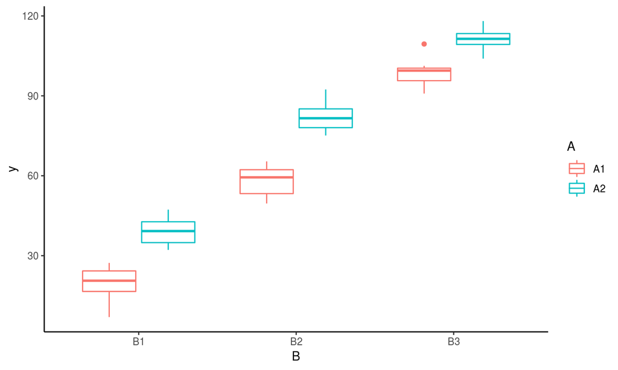

## Exploren ANOVAS

Graficaremos con la funcion `InterPlot`

```r
InterPlot <- function(DF) {
    require(tidyverse)
    DF <- group_by(DF, A, B) %>% summarize(MeanY = mean(y), SDy = sd(y))
    ggplot(DF, aes(x = B, y = MeanY, group = A)) + geom_point(aes(color = A)) +
        geom_errorbar(aes(color = A, ymax = MeanY + SDy, ymin = MeanY -
            SDy)) + geom_line(aes(color = A)) + theme_classic()
}
```

## Exploren ANOVAS

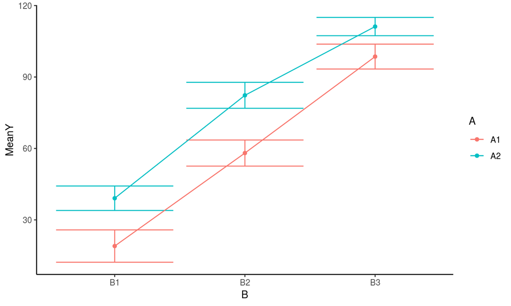

```r
InterPlot(DF)
```

## Exploren ANOVAS

```r
anova(aov(y ~ A*B, data = DF))
```

```
## Analysis of Variance Table
##
## Response: y
##           Df Sum Sq Mean Sq  F value    Pr(>F)
## A          1   5403  5402.9 186.0663 < 2.2e-16 ***
## B          2  57634 28816.9 992.4053 < 2.2e-16 ***
## A:B        2    348   173.9   5.9887  0.004477 **
## Residuals 54   1568    29.0
## ---
## Signif. codes:  0 '***' 0.001 '**' 0.01 '*' 0.05 '.' 0.1 ' ' 1
```

```r
anova(aov(y ~ B*A, data = DF))
```

```
## Analysis of Variance Table
##
## Response: y
##           Df Sum Sq Mean Sq  F value    Pr(>F)
## B          2  57634 28816.9 992.4053 < 2.2e-16 ***
## A          1   5403  5402.9 186.0663 < 2.2e-16 ***
## B:A        2    348   173.9   5.9887  0.004477 **
## Residuals 54   1568    29.0
## ---
## Signif. codes:  0 '***' 0.001 '**' 0.01 '*' 0.05 '.' 0.1 ' ' 1
```

```r
Anova(aov(y ~ A*B, data = DF), type = 2)
```

```
## Anova Table (Type II tests)
##
## Response: y
##           Sum Sq Df  F value    Pr(>F)
## A           5403  1 186.0663 < 2.2e-16 ***
## B          57634  2 992.4053 < 2.2e-16 ***
## A:B          348  2   5.9887  0.004477 **
## Residuals   1568 54
## ---
## Signif. codes:  0 '***' 0.001 '**' 0.01 '*' 0.05 '.' 0.1 ' ' 1
```

```r
Anova(aov(y ~ A*B, data = DF), type = 3)
```

```
## Anova Table (Type III tests)
##
## Response: y
##             Sum Sq Df  F value    Pr(>F)
## (Intercept)   3615  1 124.5079 1.226e-15 ***
## A             2016  1  69.4315 2.877e-11 ***
## B            31654  2 545.0532 < 2.2e-16 ***
## A:B            348  2   5.9887  0.004477 **
## Residuals     1568 54
## ---
## Signif. codes:  0 '***' 0.001 '**' 0.01 '*' 0.05 '.' 0.1 ' ' 1
```